# Finding The Strongest Pokémon Using Battle Simualtion and Capital Asset Pricing Model

Charin Polpanumas

March 14, 2016

# 1 The Big Idea

2016 is a great year to be a Pokémon fan. Pokémon Sun and Moon are expected to be release during [the holiday season](http://www.pokemon.com/us/pokemon-video-games/pokemon-sun-and-pokemon-moon/) and Niantic’s [Pokémon Go](http://www.pokemon.com/us/pokemon-video-games/pokemon-go/) due some time later this year. The time has come for us to answer one of the most important questions in life, the one that has brought about most heated discussions for elementary schoolers and grown-ups alike: *What is the strongest Pokémon of all time?*

We set out to answer this question by simulating battles for all Pokémon from Generation I to VI, then calculate their `variance-adjusted average win rate`, in the tradition of the [Sharpe ratio](http://www.investopedia.com/terms/s/sharperatio.asp) often employed in portfolio analysis. The data is obtained from the [Pokémon Database](http://pokemondb.net) including type advatages, Pokédex and moves database. All 800 Pokémons underwent 100 with one another resulting in 800 x 800 x 100 battles simulated in total. We then computed the average variance-adjusted win rates and rank all Pokémons accordingly.

# 2 Data Processing

We scraped dual-type advantage tables, Pokémon statistics, and power and accuracy of all moves from [Pokémon Database](http://pokemondb.net). Then process them for our battle simulation function.

## 2.1 Required R Libraries

```r
library(magrittr) #for %>%
library(rvest) #for scraping
library(plyr) #for data frame operations
library(knitr) #for nice table
library(ggplot2) #for plotting
```

## 2.2 Scrape Type Advantages

This includes type advantages for all type combinations of Pokémons. The first ten entries are displayed below. Rows denote defending and columns denote attacking types.

```r
#Scrape single type advantages table
url <- "http://pokemondb.net/type"
type_adv <- url %>%
  read_html() %>%
  html_nodes(xpath='/html/body/article/div[2]/div[2]/table') %>%
  html_table() %>%
  as.data.frame()

#Set type to be used as column names
types<-type_adv$DEFENSE..ATTACK..


#Scrape dual type advatnages table
url <- "http://pokemondb.net/type/dual"
d_type_adv <- url %>%
  read_html() %>%
  html_nodes(xpath='//*[@id="dualtypechart"]') %>%
  html_table() %>%
  as.data.frame()

#Get rid of tabs on dual types
d_type_adv$ATTACK........DEFENSE..<-gsub('\t','',d_type_adv$ATTACK........DEFENSE..)
d_type_adv$ATTACK........DEFENSE..<-gsub('-','',d_type_adv$ATTACK........DEFENSE..)

#Get rid of pokemon no. row
d_type_adv<-d_type_adv[,-2]

#Get rid of extra headers
extra_ind<-grep('ATTACK →\nDEFENSE ↴',d_type_adv$ATTACK........DEFENSE..)
d_type_adv<-d_type_adv[-extra_ind,]

#Set dual types
d_types<-d_type_adv$ATTACK........DEFENSE..

#Get rid of type column
d_type_adv<-d_type_adv[,-1]

#Convert to fraction symbols to decimals
for (i in 1:dim(d_type_adv)[1]){
    for (j in 1:dim(d_type_adv)[2]){
        d_type_adv[i,j]<-ifelse(d_type_adv[i,j]==''|is.na(d_type_adv[i,j]),
                              1,
                              ifelse(d_type_adv[i,j]=="½",0.5,
                              ifelse(d_type_adv[i,j]=="¼",0.25,
                                     d_type_adv[i,j])))

    }
}

#Convert to numeric
d_type_adv<-as.data.frame(sapply(d_type_adv,as.numeric))

#Rename rows and columns
colnames(d_type_adv)<-types
rownames(d_type_adv)<-d_types

#Print 10
kable(head(d_type_adv,10),col.names = substr(types,1,3))
```

|  | Nor | Fir | Wat | Ele | Gra | Ice | Fig | Poi | Gro | Fly | Psy | Bug | Roc | Gho | Dra | Dar | Ste | Fai |
| --- | --- | --- | --- | --- | --- | --- | --- | --- | --- | --- | --- | --- | --- | --- | --- | --- | --- | --- |
| Normal | 1 | 1.0 | 1.0 | 1.0 | 1.0 | 1.0 | 2 | 1.0 | 1.0 | 1.0 | 1 | 1.0 | 1.0 | 0 | 1 | 1.0 | 1.0 | 1.0 |
| NormalFire | 1 | 0.5 | 2.0 | 1.0 | 0.5 | 0.5 | 2 | 1.0 | 2.0 | 1.0 | 1 | 0.5 | 2.0 | 0 | 1 | 1.0 | 0.5 | 0.5 |
| NormalWater | 1 | 0.5 | 0.5 | 2.0 | 2.0 | 0.5 | 2 | 1.0 | 1.0 | 1.0 | 1 | 1.0 | 1.0 | 0 | 1 | 1.0 | 0.5 | 1.0 |
| NormalElectric | 1 | 1.0 | 1.0 | 0.5 | 1.0 | 1.0 | 2 | 1.0 | 2.0 | 0.5 | 1 | 1.0 | 1.0 | 0 | 1 | 1.0 | 0.5 | 1.0 |
| NormalGrass | 1 | 2.0 | 0.5 | 0.5 | 0.5 | 2.0 | 2 | 2.0 | 0.5 | 2.0 | 1 | 2.0 | 1.0 | 0 | 1 | 1.0 | 1.0 | 1.0 |
| NormalIce | 1 | 2.0 | 1.0 | 1.0 | 1.0 | 0.5 | 4 | 1.0 | 1.0 | 1.0 | 1 | 1.0 | 2.0 | 0 | 1 | 1.0 | 2.0 | 1.0 |
| NormalFighting | 1 | 1.0 | 1.0 | 1.0 | 1.0 | 1.0 | 2 | 1.0 | 1.0 | 2.0 | 2 | 0.5 | 0.5 | 0 | 1 | 0.5 | 1.0 | 2.0 |
| NormalPoison | 1 | 1.0 | 1.0 | 1.0 | 0.5 | 1.0 | 1 | 0.5 | 2.0 | 1.0 | 2 | 0.5 | 1.0 | 0 | 1 | 1.0 | 1.0 | 0.5 |
| NormalGround | 1 | 1.0 | 2.0 | 0.0 | 2.0 | 2.0 | 2 | 0.5 | 1.0 | 1.0 | 1 | 1.0 | 0.5 | 0 | 1 | 1.0 | 1.0 | 1.0 |
| NormalFlying | 1 | 1.0 | 1.0 | 2.0 | 0.5 | 2.0 | 1 | 1.0 | 0.0 | 1.0 | 1 | 0.5 | 2.0 | 0 | 1 | 1.0 | 1.0 | 1.0 |

## 2.3 Scrape Pokédex

This includes all Pokémons from Generation I to Generation 6 including their mega, primal and other known special forms. This resulted in 800 Pokémons in total. The data used for analysis include HP, Attack, Defense, Sp.Atk, Sp.Def and Speed of all Pokémons. The first ten entries are displayed below.

```r
#Scrape pokedex
url <- "http://pokemondb.net/pokedex/all"
pokemon <- url %>%
  read_html() %>%
  html_nodes(xpath='//*[@id="pokedex"]') %>%
  html_table() %>%
  as.data.frame()

#Print first ten
kable(head(pokemon,10))
```

| X. | Name | Type | Total | HP | Attack | Defense | Sp..Atk | Sp..Def | Speed |
| --- | --- | --- | --- | --- | --- | --- | --- | --- | --- |
| 1 | Bulbasaur | GrassPoison | 318 | 45 | 49 | 49 | 65 | 65 | 45 |
| 2 | Ivysaur | GrassPoison | 405 | 60 | 62 | 63 | 80 | 80 | 60 |
| 3 | Venusaur | GrassPoison | 525 | 80 | 82 | 83 | 100 | 100 | 80 |
| 3 | VenusaurMega Venusaur | GrassPoison | 625 | 80 | 100 | 123 | 122 | 120 | 80 |
| 4 | Charmander | Fire | 309 | 39 | 52 | 43 | 60 | 50 | 65 |
| 5 | Charmeleon | Fire | 405 | 58 | 64 | 58 | 80 | 65 | 80 |
| 6 | Charizard | FireFlying | 534 | 78 | 84 | 78 | 109 | 85 | 100 |
| 6 | CharizardMega Charizard X | FireDragon | 634 | 78 | 130 | 111 | 130 | 85 | 100 |
| 6 | CharizardMega Charizard Y | FireFlying | 634 | 78 | 104 | 78 | 159 | 115 | 100 |
| 7 | Squirtle | Water | 314 | 44 | 48 | 65 | 50 | 64 | 43 |

## 2.4 Process Types for Each Pokémon

We process primary and secondary types of each Pokémon for the battle simulation function.

```r
pokemon$Type1 <- rep(NA,dim(pokemon)[1])
pokemon$Type2 <- rep(NA,dim(pokemon)[1])

for (i in types){
    for (j in 1:dim(pokemon)[1]){
        if(grepl(i,pokemon[j,'Type'])){
            if (is.na(pokemon[j,'Type1'])){
                 pokemon[j,'Type1']<-i
            }
            else {
                pokemon[j,'Type2']<-i
            }
        }
    }
}
```

# 3 The Definitive Guide to Type Advantages

We explore which type combinations have the top advantages in attack and defense. This gives a rough sketch on how devastating and how durable each type of Pokémons is.

## 3.1 What Types Have The Most Effective Attack?

This shows the average effectiveness of moves associated with each type. For instance, `Ground` type has the highest average effectiveness of moves at 1.33. This means that on average a `Ground` move will hit 133% its power.

```r
b_attack<-data.frame(sort(colMeans(d_type_adv),decreasing = TRUE))
kable(b_attack,col.names = 'Average Effectiveness of Moves')
```

|  | Average Effectiveness of Moves |
| --- | --- |
| Ground | 1.3317901 |
| Rock | 1.2746914 |
| Fire | 1.2129630 |
| Ice | 1.2129630 |
| Water | 1.1574074 |
| Flying | 1.1574074 |
| Fairy | 1.1574074 |
| Fighting | 1.1466049 |
| Steel | 1.0987654 |
| Dark | 1.0462963 |
| Ghost | 1.0447531 |
| Psychic | 0.9891975 |
| Dragon | 0.9398148 |
| Electric | 0.9351852 |
| Grass | 0.9320988 |
| Bug | 0.9320988 |
| Poison | 0.8827160 |
| Normal | 0.7916667 |

## 3.2 What Types Has The Most Solid Defense?

This shows the average effectiveness of moves associated with each type against all combinations of type. For instance, `SteelFairy` type has the lowest average effectiveness of moves at 0.74. This means that on average a `SteelFairy` Pokémons will get hit with 74% of move power.

```r
b_defense<-data.frame(sort(rowMeans(d_type_adv)))
kable(head(b_defense,10),col.names = 'Average Effectiveness Against Moves')
```

|  | Average Effectiveness Against Moves |
| --- | --- |
| SteelFairy | 0.7361111 |
| FairySteel | 0.7361111 |
| FlyingSteel | 0.7500000 |
| SteelFlying | 0.7500000 |
| GhostSteel | 0.7916667 |
| DragonSteel | 0.7916667 |
| SteelGhost | 0.7916667 |
| SteelDragon | 0.7916667 |
| WaterSteel | 0.8055556 |
| SteelWater | 0.8055556 |

## 3.3 Average Accuracy and Power of Moves

We also calculate the average base power and accuracy of all moves. This resulted in average base power 75.06 and 95.24% base accuracy. We will use this in our battle simulation function in the next section.

```r
url <- "http://pokemondb.net/move/all"
moves <- url %>%
  read_html() %>%
  html_nodes(xpath='//*[@id="moves"]') %>%
  html_table() %>%
  as.data.frame()

#Convert power and accuracy to numeric
moves$Power<-sapply(moves$Power,as.numeric)
moves$Acc.<-sapply(moves$Acc.,as.numeric)
#Get their averages
m_power<-mean(moves$Power,na.rm = TRUE)
m_acc<-mean(moves$Acc.,na.rm = TRUE)
m_power
```

```
## [1] 75.05833
```

```r
m_acc
```

```
## [1] 95.23702
```

# 4 Battle Simulation

## 4.1 Battle Simulation Function

```r
#Battle simulation function
#Generation VI rules
#Pokemon LV 100
#Using STAB move with m_power and m_acc with the best type advantage
#Stage 1 critical (6.25%)
#No nature or ability is taken into account
#All IVs = 31, All EVs = 252
#Fights for 100 times each pair

#Damage without type advantage, critical, random and accuracy
damage<-function(atk,def,power=m_power,level=100){
    #STAB * Critical * rand[0.85,1]
    STAB <- 1.5
    (((2*level+10)/250)*(atk/def)*power+2)*1.5
}

#Damage modifier, aka critical, random and accuracy
mod <- function(acc=m_acc){
    crit <-ifelse(runif(1)<=0.0625,1.5,1)
    hit <- ifelse(runif(1)<=acc,1,0)
    mod <- 1.5*crit*hit*runif(1,min=0.85,max=1)
    return(mod)
}

stat_fol <- function(base,iv=31,ev=252,level=100){
    ((2*base+iv+ev/4)*level/100)+5
}

battle<-function(poke1,poke2,times=100,level=100,verbose=FALSE){
    #poke1 stats
    hp1 <- stat_fol(pokemon[pokemon$Name==poke1,'HP'])+5+level
    atk1 <- stat_fol(pokemon[pokemon$Name==poke1,'Attack'])
    def1 <- stat_fol(pokemon[pokemon$Name==poke1,'Defense'])
    spatk1 <- stat_fol(pokemon[pokemon$Name==poke1,'Sp..Atk'])
    spdef1 <- stat_fol(pokemon[pokemon$Name==poke1,'Sp..Def'])
    spd1 <- stat_fol(pokemon[pokemon$Name==poke1,'Speed'])
    type1<-pokemon[pokemon$Name==poke1,'Type']
    type1_1<-pokemon[pokemon$Name==poke1,'Type1']
    type2_1<-pokemon[pokemon$Name==poke1,'Type2']

    #poke2 stats
    hp2 <- stat_fol(pokemon[pokemon$Name==poke2,'HP'])+5+level
    atk2 <- stat_fol(pokemon[pokemon$Name==poke2,'Attack'])
    def2 <- stat_fol(pokemon[pokemon$Name==poke2,'Defense'])
    spatk2 <- stat_fol(pokemon[pokemon$Name==poke2,'Sp..Atk'])
    spdef2 <- stat_fol(pokemon[pokemon$Name==poke2,'Sp..Def'])
    spd2 <- stat_fol(pokemon[pokemon$Name==poke2,'Speed'])
    type2<-pokemon[pokemon$Name==poke2,'Type']
    type1_2<-pokemon[pokemon$Name==poke2,'Type1']
    type2_2<-pokemon[pokemon$Name==poke2,'Type2']

    #Choose most deadly poke1 move
    type_mod1_1 <-d_type_adv[type2,type1_1]
    type_mod2_1 <- d_type_adv[type2,type2_1]

    atk_type1_1<-type_mod1_1*damage(atk1,def2)
    spatk_type1_1<-type_mod1_1*damage(spatk1,spdef2)
    atk_type2_1<-type_mod2_1*damage(atk1,def2)
    spatk_type2_1<-type_mod2_1*damage(spatk1,spdef2)

    final_atk1 <- max(atk_type1_1,spatk_type1_1,
                      atk_type2_1,spatk_type2_1,na.rm = TRUE)

    #Choose most deadly poke2 move
    type_mod1_2 <-d_type_adv[type1,type1_2]
    type_mod2_2 <- d_type_adv[type1,type2_2]

    atk_type1_2<-type_mod1_2*damage(atk2,def1)
    spatk_type1_2<-type_mod1_2*damage(spatk2,spdef1)
    atk_type2_2<-type_mod2_2*damage(atk2,def1)
    spatk_type2_2<-type_mod2_2*damage(spatk2,spdef1)

    final_atk2 <- max(atk_type1_2,spatk_type1_2,
                      atk_type2_2,spatk_type2_2,na.rm = TRUE)

    #If they can't damage each other, return a draw
    if (final_atk1==0 &final_atk2==0) return(0.5)

    #Battle till faint
    win1<-0
    win2<-0
    for (i in 1:times){
        temp1 <-hp1
        temp2 <-hp2
        count <-0
        while (TRUE){
            #if poke2 has more speed add it moves first
            if (spd2>spd1){
                #poke2 hits
                temp1=temp1-final_atk2*mod()
                if (verbose) print(paste(poke2,'attacked for',final_atk2*mod(),sep=' '))
                if (temp1<=0) {
                    win2=win2+1
                    if (verbose) print(paste(poke2,'wins at HP',temp2,sep=' '))
                    break
                }
                #poke1 hits
                temp2=temp2-final_atk1*mod()
                if (verbose) print(paste(poke1,'attacked for',final_atk1*mod(),sep=' '))
                if (temp2<=0) {
                    win1=win1+1
                    if (verbose) print(paste(poke1,'wins at HP',temp1,sep=' '))
                    break
                }
            }
            #if poke2 has more speed add it moves first
            else if(spd1>spd2){
                #poke1 hits
                temp2=temp2-final_atk1*mod()
                if (verbose) print(paste(poke1,'attacked for',final_atk1*mod(),sep=' '))
                if (temp2<=0) {
                    win1=win1+1
                    if (verbose) print(paste(poke1,'wins at HP',temp1,sep=' '))
                    break
                }
                #poke2 hits
                temp1=temp1-final_atk2*mod()
                if (verbose) print(paste(poke2,'attacked for',final_atk2*mod(),sep=' '))
                if (temp1<=0) {
                    win2=win2+1
                    if (verbose) print(paste(poke2,'wins at HP',temp2,sep=' '))
                    break
                }
            }
            #Otherwise use a tiebreaker
            else{
                #If true, poke1 hits first
                if (sample(c(TRUE,FALSE))[1]){
                    #poke1 hits
                    temp2=temp2-final_atk1*mod()
                    if (verbose) print(paste(poke1,'attacked for',final_atk1*mod(),sep=' '))
                    if (temp2<=0) {
                        win1=win1+1
                        if (verbose) print(paste(poke1,'wins at HP',temp1,sep=' '))
                        break
                    }
                    #poke2 hits
                    temp1=temp1-final_atk2*mod()
                    if (verbose) print(paste(poke2,'attacked for',final_atk2*mod(),sep=' '))
                    if (temp1<=0) {
                        win2=win2+1
                        if (verbose) print(paste(poke2,'wins at HP',temp2,sep=' '))
                        break
                    }
                }
                #If false, poke2 hits first
                else{
                    #poke2 hits
                    temp1=temp1-final_atk2*mod()
                    if (verbose) print(paste(poke2,'attacked for',final_atk2*mod(),sep=' '))
                    if (temp1<=0) {
                        win2=win2+1
                        if (verbose) print(paste(poke2,'wins at HP',temp2,sep=' '))
                        break
                    }
                    #poke1 hits
                    temp2=temp2-final_atk1*mod()
                    if (verbose) print(paste(poke1,'attacked for',final_atk1*mod(),sep=' '))
                    if (temp2<=0) {
                        win1=win1+1
                        if (verbose) print(paste(poke1,'wins at HP',temp1,sep=' '))
                        break
                    }
                }
            }
        }
    }
    return(win1/times)
}
```

## 4.2 Simulate Battles for All Pairs of Pokémons

We simulate 100 battles for each pair of Pokémons, resulting in 800 x 800 x 100 total battles simulated. Then we record the `win rate` for each pair. For instance, if we pitch Bulbasaur against Caterpie and the function returns 0.99, it means that Bulbasaur has a 99% `win rate` against Caterpie as a result of the 100 battles. When the same Pokémon is matched, such as Pikachu vs Pikachu, we assume a draw. The `result` of all battles is saved to `result.rds` for future reference.

```r
if (!file.exists('result.rds')){
   result <- data.frame(matrix(1:800/100,nrow=dim(pokemon)[1],ncol=dim(pokemon)[1]))
    rownames(result)<-pokemon$Name
    colnames(result)<-pokemon$Name
    count<-0
    for (i in pokemon$Name){
        for (j in pokemon$Name){
            #Same pokemon assumes draw
            if (i==j){
                result[i,j]<-0.5
            } else{
            result[i,j]<-battle(i,j)
            }
            count=count+1
            print(paste(count,i,j,sep=' '))
        }
    }

    #Save to RDS
    saveRDS(result,'result.rds')
} else {
    result<-readRDS('result.rds')
}
```

## 4.3 Best Variance-Adjusted Average Win Rate

At the core of every strongest-Pokémon argument is how you define *strongest*: the toughest wall, the most destructive sweeper, the most advantageous type, and the list go on. Here we define *strongest* as the best `variance-adjusted average win rate`. The rationale is two-fold. First, it should be straight forward that after 100 battles with each Pokémon, a Pokémon with a high `average win rate` would be strong. However, we need to take into account the *variability* of its win rate. For instance, compare a Pokémon that wins all of its battles 50% of times with a Pokémon that wins half of its battles 100% of times but loses the rest 100% of times. Their `average win rate` is both 50% but we would rather have a more consistent Pokémon that is the former. Below is the `average win rate` vs `standard deviation of win rate` plot of all Pokémons by primary types.

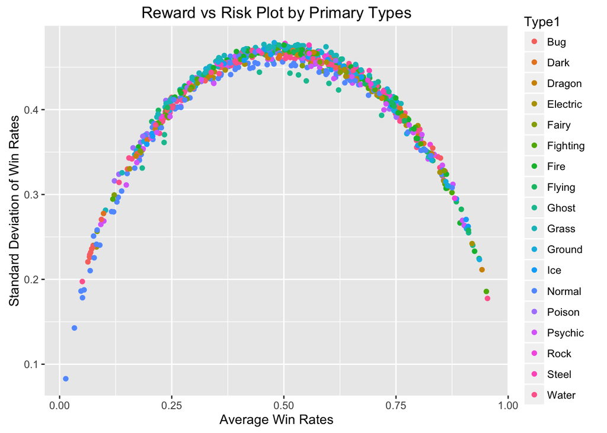

```r
#Row SD function
rowSDs <- function(x) {
  sqrt(rowSums((x - rowMeans(x))^2)/(dim(x)[2] - 1))
}

#Plot average win rate vs standard deviation
rank_poke<-cbind(pokemon,winrate=rowMeans(result),sd=rowSDs(result))
g<-ggplot(data=rank_poke,aes(x=winrate,y=sd))
g+geom_point(aes(color=Type1))+xlab('Average Win Rates')+
    ylab('Standard Deviation of Win Rates')+
    ggtitle("Reward vs Risk Plot by Primary Types")
```

Therefore, we adopted the Sharpe Ratio, a variance-adjusted return metric for an asset in capital asset pricing model. We use the `average win rate` of all battles (yes, all 64 million of them) as the `benchmark win rate`. We calculate our `variance-adjusted average win rate` by subtracting the `average win rate` of each Pokémon by `excess win rate per standard deviation` of it.

This way, if a stranger challenges you to a 1-on-1 Pokémon battle and you don’t know what he has, you know that your best and most consistent chance of winning is to choose Palkia.

```r
#Benchmark return
b_return <- mean(rowMeans(result))

#Sharpe ratio
sharpe <- (rowMeans(result)-b_return)/rowSDs(result)

#Ranking according to variance-adjusted price
sharped <- data.frame(sort(sharpe,decreasing=TRUE))
kable(head(sharped,20),col.names='Shrape Ratio')
```

|  | Shrape Ratio |
| --- | --- |
| Palkia | 2.556832 |
| MewtwoMega Mewtwo X | 2.430361 |
| Dialga | 2.089522 |
| GarchompMega Garchomp | 1.951607 |
| RayquazaMega Rayquaza | 1.938152 |
| Reshiram | 1.823712 |
| GiratinaAltered Forme | 1.752902 |
| Zekrom | 1.732843 |
| GiratinaOrigin Forme | 1.615160 |
| Yveltal | 1.595670 |
| MetagrossMega Metagross | 1.588712 |
| Garchomp | 1.568079 |
| KyuremWhite Kyurem | 1.566185 |
| LatiosMega Latios | 1.532086 |
| GengarMega Gengar | 1.524422 |
| KyuremBlack Kyurem | 1.502007 |
| LatiasMega Latias | 1.477559 |
| CharizardMega Charizard X | 1.473507 |
| SalamenceMega Salamence | 1.400154 |
| Rayquaza | 1.319142 |